# Basic Data Reduction with dplyr

10/28/2019

## Google Quantitative User Experience Research

https://careers.google.com/jobs#!t=jo&jid=/google/quantitative-user-experience-researcher-google-building-41-1600-amphitheatre-1285660001&

“Develop code and statistical models to understand user experience.”

“Experience in a programming language commonly used for data manipulation and computational statistics (such as Python, R, Matlab, C++, Java or Go), and with SQL.”

`dplyr` is a simple way to do SQL-type data manipulation

## dplyr for Data Reduction

### dplyr as grammar of data reduction

– `select` to remove variables (i.e., columns)

– `filter` to subset the data and remove observations (i.e., rows)

– `mutate` to create new variables

– `summarise` to aggregate data across rows (i.e., mean of values)

– `group_by` to group variables for `mutate` and `summarise`

– `do` to fit a model or create a plot each group of the data

– `join` to combine datasets

## Pipe (i.e., `%>%`) for Combining Operations

– `%>%` acts as “and then” to chain operations

– `sleep.df %>% summarise(mean(Reaction))` ~ take sleep dataframe “and then” calculate mean of Reaction

– More comprehensible than the equivalent: `summarise(sleep.df, mean(Reaction))`

– Many operations can be chained with `%>%` to create data reduction “sentences”

– `sleep.df %>% filter(Reaction>250) %>% group_by(Subject) %>% summarise(m.rt = mean(Reaction))`

More understandable?

– `summarise(group_by(filter(sleep.df, Reaction>250), Subject), mean(Reaction))`

## `select` to Remove Variables

```r
sleep.df = sleepstudy

head(sleep.df)
```

```
##   Reaction Days Subject
## 1 249.5600    0     308
## 2 258.7047    1     308
## 3 250.8006    2     308
## 4 321.4398    3     308
## 5 356.8519    4     308
## 6 414.6901    5     308
```

```r
nort.sleep.df = sleep.df %>% select(-Reaction)
head(nort.sleep.df)
```

```
##   Days Subject
## 1    0     308
## 2    1     308
## 3    2     308
## 4    3     308
## 5    4     308
## 6    5     308
```

## `filter` to Identify Outliers

```r
longrt_sleep.df = sleep.df %>% filter(Reaction>450)

head(longrt_sleep.df)
```

```
##   Reaction Days Subject
## 1 466.3535    9     308
## 2 454.1619    6     332
## 3 455.8643    8     337
## 4 458.9167    9     337
```

## `mutate` to Create New Variables

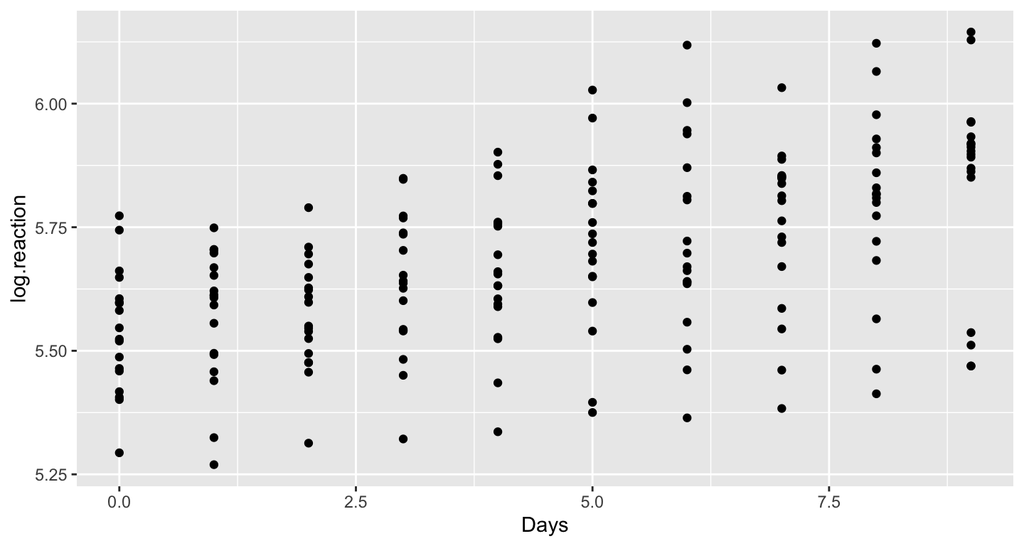

```r
sleep.df = sleepstudy
sleep.df = sleep.df %>% mutate(log.reaction = log(Reaction))

ggplot(sleep.df, aes(Days, log.reaction)) +
  geom_point()
```

## `group_by` to Group Data for `mutate`

### Adds z-score based on each Subject

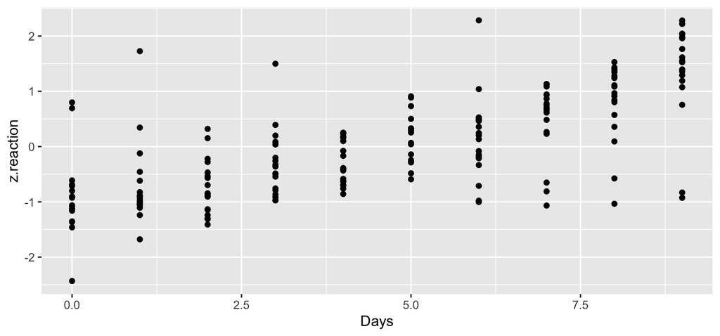

```r
sleep.df = sleep.df %>% group_by(Subject) %>%
  mutate(z.reaction = scale(Reaction))

ggplot(sleep.df, aes(Days, z.reaction)) +
  geom_point()
```

## `group_by` to Group Data for `summarise`

### Aggregates data with summary statistics

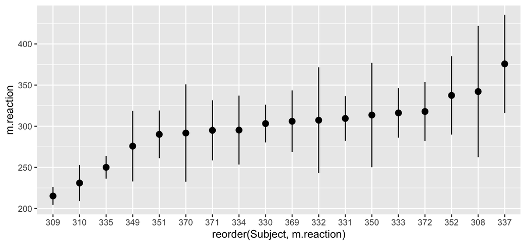

```r
s.sleep.df = sleep.df %>% group_by(Subject) %>%
  summarise(m.reaction = mean(Reaction), sd.reaction = sd(Reaction))

ggplot(s.sleep.df, aes(reorder(Subject, m.reaction), m.reaction)) +
  geom_pointrange(aes(ymin = m.reaction-sd.reaction, ymax = m.reaction+sd.reaction))
```

## `filter` to Subset the Data

### Add layer to highlight outliers

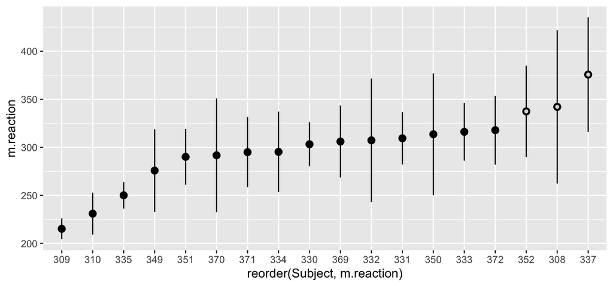

```r
r.s.sleep.df = s.sleep.df %>% filter(m.reaction>325)

ggplot(s.sleep.df, aes(reorder(Subject, m.reaction), m.reaction)) +
  geom_pointrange(aes(ymin = m.reaction-sd.reaction, ymax = m.reaction+sd.reaction)) +
  geom_point(data = r.s.sleep.df, size = 1, colour = "grey85")
```

## Exercise: Simple data aggregation

### Calculate the mean and standard deviation of Reaction by day

– Group the data by `Days` and then summarise using `mean` and `sd`

– Plot the summary data using `geom_pointrange`

– Plot with 25<sup>th</sup> and 75<sup>th</sup> quantiles if this is too easy (use `quantile` )

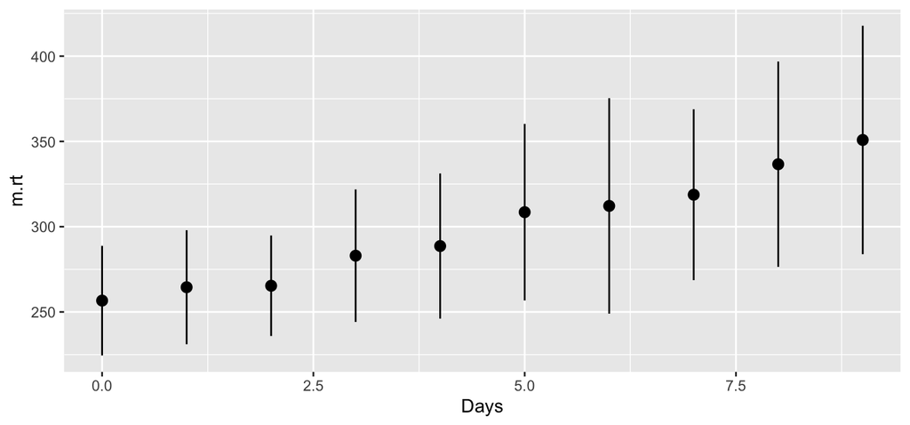

## `do` to Fit Model to Groups of Data

### Fit regression model to each participant

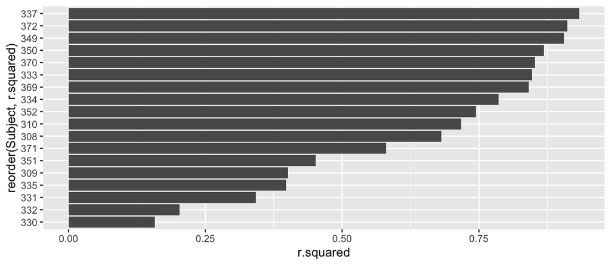

```r
models = sleep.df %>% group_by(Subject) %>%
  do(fit = lm(Reaction ~ Days, data = ., na.action = na.exclude))

s.model = models %>% glance(fit) # Extracts summary of models

ggplot(s.model, aes(reorder(Subject, r.squared), r.squared)) + geom_col() + coord_flip()
```

## `join` to Combine Datasets

**Mutating joins** add columns from x and y

– `inner_join(x, y)`Returns all rows of x where there are matching values of y, all columns of x and y

– `left_join(x, y)` Returns all rows of x, all columns of x and y, rows of x with no match in y get NA

– `full_join(x, y)` Returns all rows and all columns of x and y, unmatched receive NA

**Filtering joins** keep only columns from x

– `semi_join(x, y)` Return all row in x that have a matching values in y, columns of x

– `anti_join(x, y)` Return rows in x that are do NOT have a match in y, columns of x

## `join` to Combine Datasets

Use “broom” to extract model predictions and diagnostics

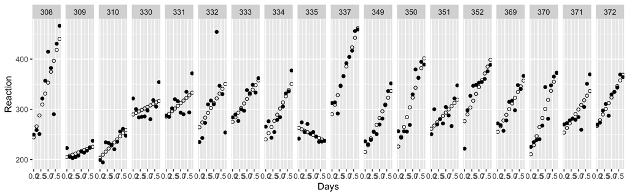

```r
library(broom)
sum.model.df = models %>% augment(fit) # Extracts summary of models
augmented.sleep.df = left_join(sleep.df, sum.model.df, by = c("Subject", "Days", "Reaction"))

ggplot(augmented.sleep.df, aes(Days, Reaction)) +
  geom_point()+
  geom_point(aes(Days, .fitted), shape = 21) +
  facet_grid(.~Subject)
```

## Pattern of Model Errors

### Residuals highlight problems

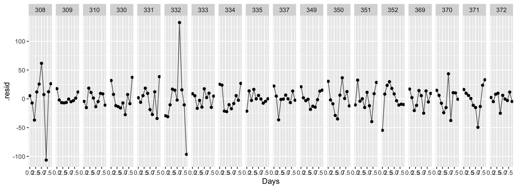

```r
ggplot(augmented.sleep.df, aes(Days, .resid)) +
  geom_point() +
  geom_line(alpha =.6) +
  facet_grid(.~Subject)
```

## Exercise

### Model and merge

– Fit a regression model for each participant and extract the r.squared value with the `glance` function

– Summarize the sleep data by person to calculate the mean reaction time

– Merge the summarized data and the r.square value and plot

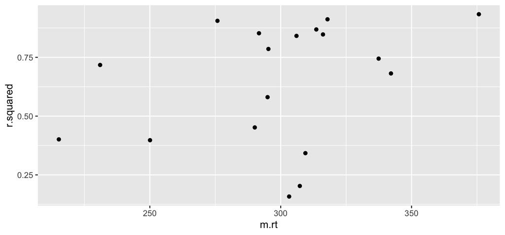

## dplyr for Data Reduction

**dplyr as grammar of data reduction**

– `select` to remove variables (i.e., columns)

– `filter` to subset the data and remove observations (i.e., rows)

– `mutate` to create new variables

– `summarise` to aggregate data across rows (i.e., mean of values)

– `group_by` to group variables for “mutate” and “summarise”

– `do` to fit a model or create a plot each group of the data

– `join` to combine datasets

**Pipe (i.e., `%>%`) for combining operations in a comprehensible way**